# Day 6 Key: More markdown, dataviz & wrangling, hypothesis tests, regression

Allison Horst

## Day 6 Materials

**Packages needed:**

- tidyverse
- RColorBrewer
- stargazer
- janitor
- ggbeeswarm

**Goals:**

- Markdown continued
- Basic data exploration graphs (hist, qqnorm)
- Data wrangling continued + group_by
- Graphs with error bars
- Explicitly ordering categorical variables
- ggplot finalization
- Creating some data from scratch
- Basic statistics (t-tests, chisq.test)
- Linear regression (OLS and MLR) + diagnostics
- Model outputs with stargazer

First: Create a new project, and open a new Rmarkdown file. Then:

### 1. Load packages

**Notes: use ‘echo = FALSE’ in code chunk header if you don’t want the CODE to show up in the knitted doc, use ‘message = FALSE’ if you don’t want any MESSAGES showing up in the output doc.**

```r
library(tidyverse)
library(RColorBrewer)
library(stargazer)
library(janitor)
library(ggbeeswarm)
```

### 2. Load data

Remember to drop the file into the project folder first, this puts it right into your working directory. Then you don’t have to worry about the absolute path, because R will know right where to look!

```r
lobsters <- read_csv("lter_lobster.csv") %>%
  clean_names()
```

### 3. Basic data exploration tools

It’s always important to look at our data. Let’s say we want to look at the distribution of lobster sizes at all five sites (ignoring that there are different years, transects, etc).

Let’s group the data and do some visualization using ggplot for exploratory data analysis.

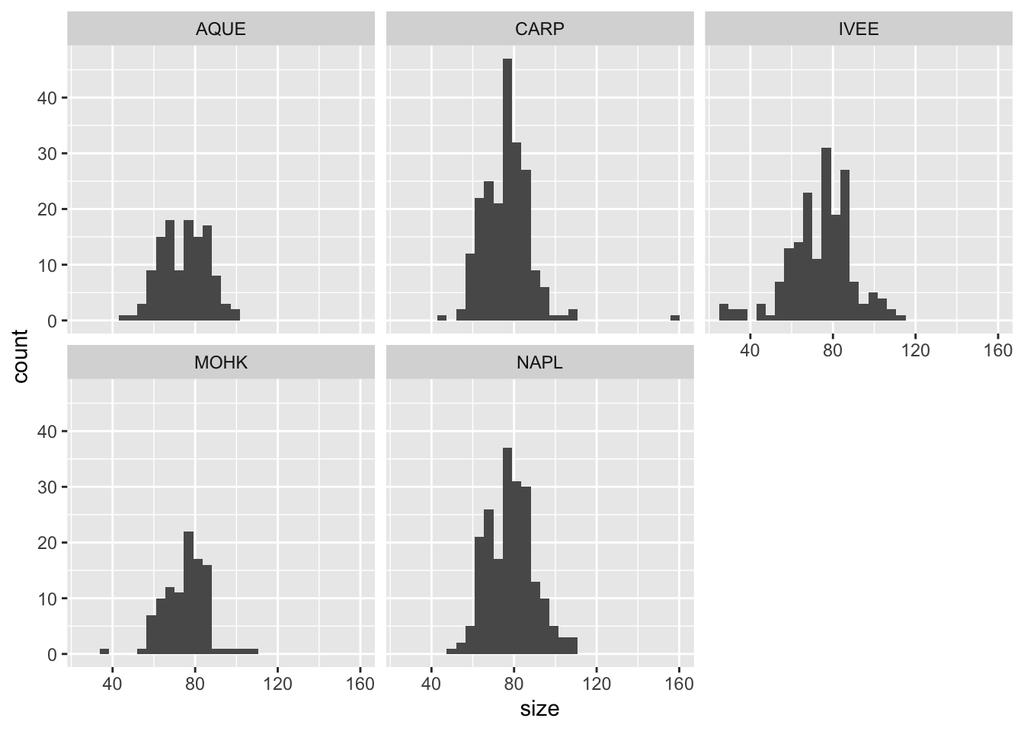

```r
lobster_eda <- lobsters

# Histograms are always a great idea. They show us the general structure (distribution) of our data.
ggplot(lobster_eda, aes(size)) +
  geom_histogram() +
  facet_wrap(~site)
```

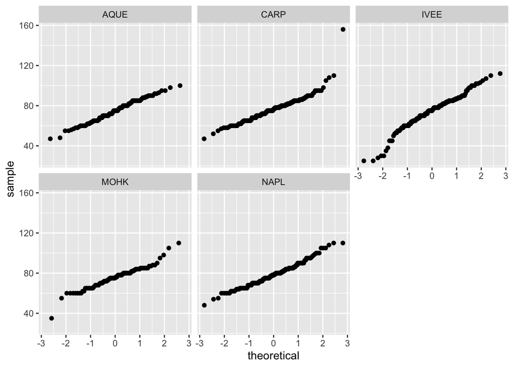

```r
# QQ plots are ideal for assessing normality. The closer the relationship to linear, the closer the data are to normally distributed.
ggplot(lobster_eda, aes(sample = size)) +
  geom_qq() +
  facet_wrap(~site)
```

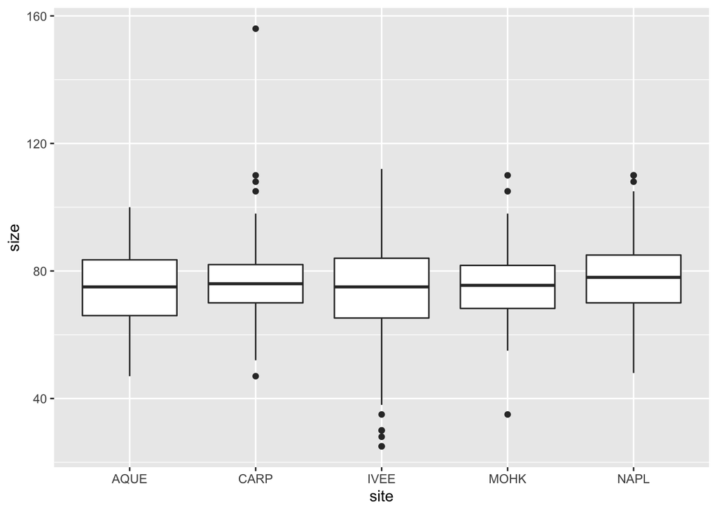

```r
# Boxplots show important characteristics like max, min, 25th and 75th quantiles, and median. Good for evaluating outliers, etc.
ggplot(lobster_eda, aes(x = site, y = size)) +
  geom_boxplot()
```

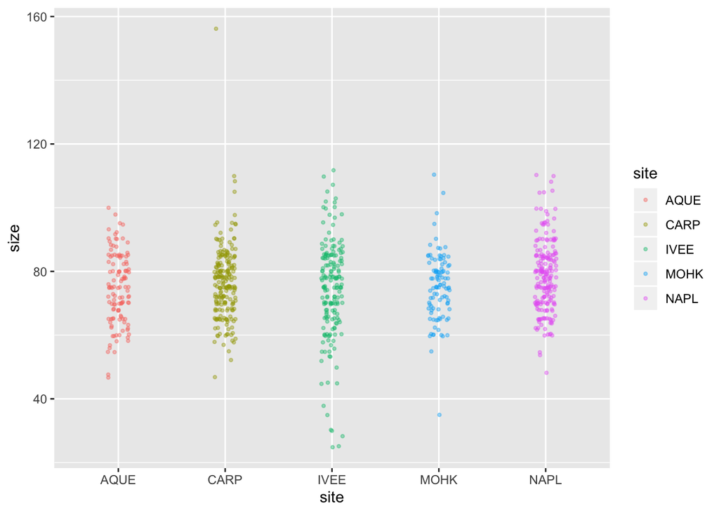

```r
# Jitterplots are TOTALLY unbiased because they show EVERYTHING
ggplot(lobster_eda, aes(x = site, y = size, color = site)) +
  geom_jitter(width = 0.1, alpha = 0.4, size = 0.8)
```

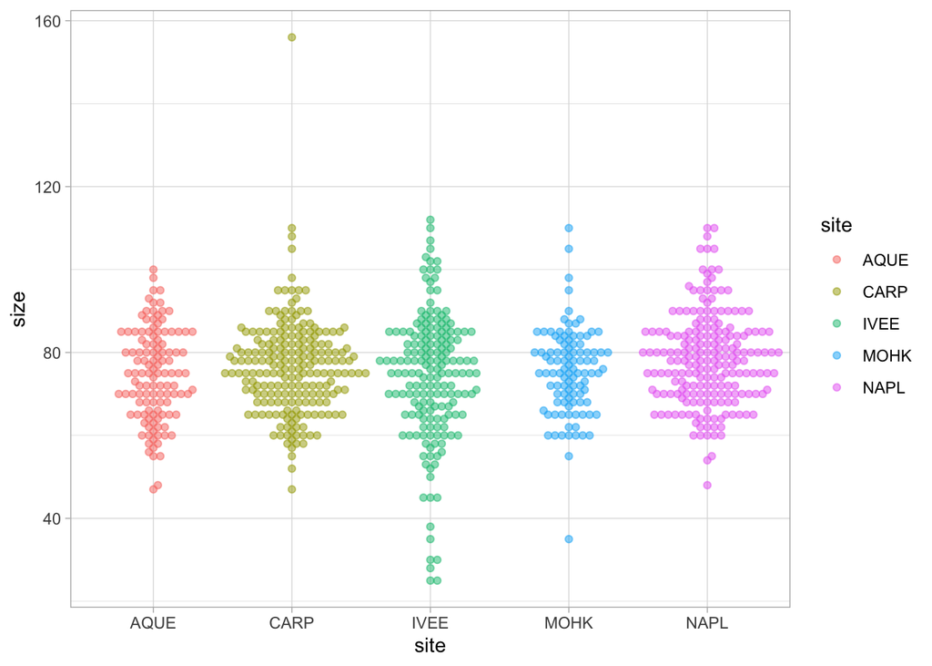

```r
# Even better though...ggbeeswarm?

ggplot(lobster_eda, aes(x = site, y = size, color = site)) +
  geom_beeswarm(alpha = 0.5) +
  theme_light()
```

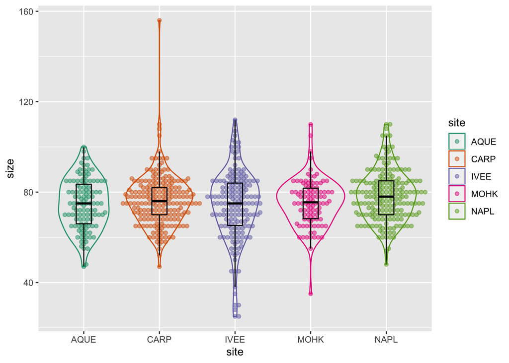

```r
# We can also add different types of graphs on top of one-another, as long as the graph types are compatible. Like a beeswarm plot and a boxplot and a violin plot?

# DISCLAIMER: this is totally overcomplicated and overplotted, and only meant to show technically how we can add additional geom layers

ggplot(lobster_eda, aes(x = site, y = size, color = site)) +
  geom_beeswarm(pch = 21,
                alpha = 0.5,
                aes(fill = site)) +
  geom_boxplot(fill = NA,
               color = "black",
               width = 0.2,
               outlier.color = NA) +
  geom_violin(fill = NA,
              aes(color = site)) +
  scale_color_brewer(palette = "Dark2") +
  scale_fill_brewer(palette = "Dark2")
```

Now, let’s say that we want to find the mean lobster size for each SITE at each different YEAR (ignoring different transects, etc.)

### 4. Find mean and SD lobster size at each different SITE at each different YEAR using group_by with summarize()

```r
site_group <- lobsters %>%
  group_by(site, year) %>%
  summarize(
    mean_size = mean(size),
    sd_size = sd(size)
  )

site_group
```

```
## # A tibble: 15 x 4
## # Groups:   site [5]
##    site   year mean_size sd_size
##    <chr> <dbl>     <dbl>   <dbl>
##  1 AQUE   2012      71     10.2
##  2 AQUE   2013      73.3   12.7
##  3 AQUE   2014      77.7    9.98
##  4 CARP   2012      74.4   15.3
##  5 CARP   2013      75.8    8.93
##  6 CARP   2014      79.2    8.98
##  7 IVEE   2012      66.3   12.3
##  8 IVEE   2013      73.5    7.52
##  9 IVEE   2014      76.2   17.7
## 10 MOHK   2012      76.1   10.9
## 11 MOHK   2013      71.9   10.2
## 12 MOHK   2014      75.9    9.76
## 13 NAPL   2012      74.6   12.4
## 14 NAPL   2013      75.6   13.1
## 15 NAPL   2014      79.8    9.68
```

### 5. Bar graph with error bars for mean size & location (using ggplot)? But also make sure to read why dynamite plots hide way too much about the data, and should be used with caution: https://simplystatistics.org/2019/02/21/dynamite-plots-must-die/

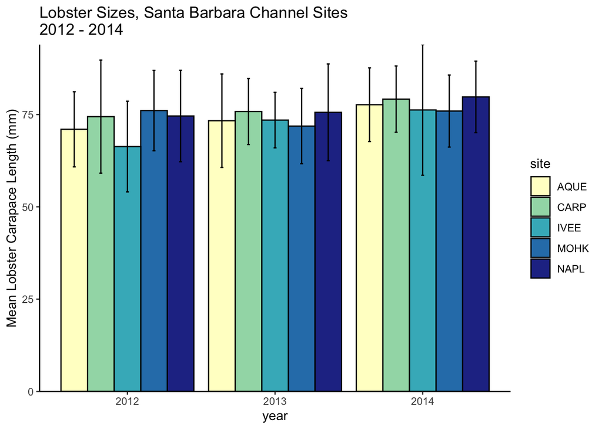

```r
lobster_plot <- ggplot(site_group, aes(x = year,
                                       y = mean_size,
                                       fill = site)) +
  geom_col(position = "dodge", color = "black") +
  scale_fill_brewer(palette = "YlGnBu") +
  geom_errorbar(aes(ymin = mean_size - sd_size,
                    ymax = mean_size + sd_size),
                width = 0.1,
                position = position_dodge(0.9)) +
  labs(y = "Mean Lobster Carapace Length (mm)") +
  theme_classic() +
  ggtitle("Lobster Sizes, Santa Barbara Channel Sites\n2012 - 2014") +
  scale_y_continuous(expand = c(0,0))


lobster_plot
```

Let’s say I’m only interested in 2012 data, and I want these to show up from LOW to HIGH on my chart.

Then I’m going to only keep data from my previous data frame where YEAR == 2012, and arrange from low to high mean size.

```r
lobsters2012 <- site_group %>%
  filter(year == 2012) %>%
  arrange(mean_size)

lobsters2012
```

```
## # A tibble: 5 x 4
## # Groups:   site [5]
##   site   year mean_size sd_size
##   <chr> <dbl>     <dbl>   <dbl>
## 1 IVEE   2012      66.3    12.3
## 2 AQUE   2012      71      10.2
## 3 CARP   2012      74.4    15.3
## 4 NAPL   2012      74.6    12.4
## 5 MOHK   2012      76.1    10.9
```

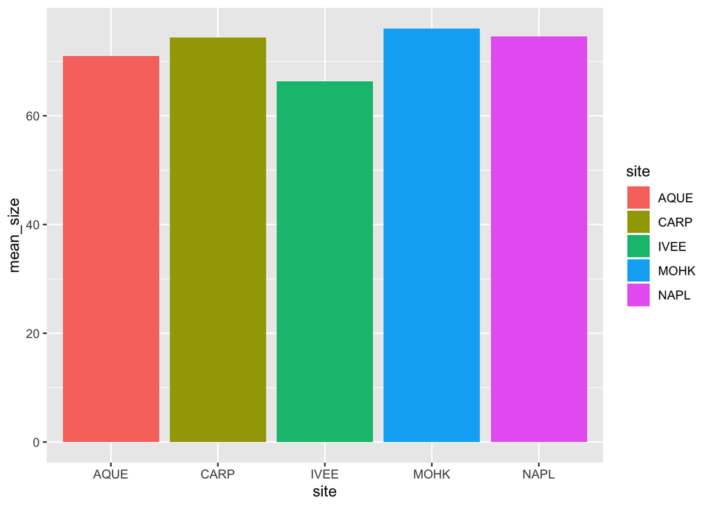

```r
# What happens if we just plot this?

ggplot(lobsters2012, aes(x = site, y = mean_size, fill = site)) +
  geom_col(position = "dodge") # It automatically arranges alphabetically by site, even though our original data frame is now arranged from low to high mean values.
```

But we want to create an ORDERED column graph. Let’s use forcats::fct_reorder()

```r
# Check the class of the 'SITE' variable
class(lobsters2012$site) # It's a character. Hmm.
```

```
## [1] "character"
```

```r
# Check the LEVELS as is:
levels(lobsters2012$site) # NULL - because this only works for factors, but it's currently a character
```

[output not shown]

```r
# Make a copy of the data frame (called lob_df) where the site column has been converted to a factor (with mutate), and reorder!
lob_df <- lobsters2012 %>%
  ungroup() %>%
  mutate(site = as.factor(site)) # At this point, still in alphabetical order (but has been converted to factor. Now we want to reorder them based on the values in mean_size)
```

Now we can use fct_reorder within ggplot2 to set the orders:

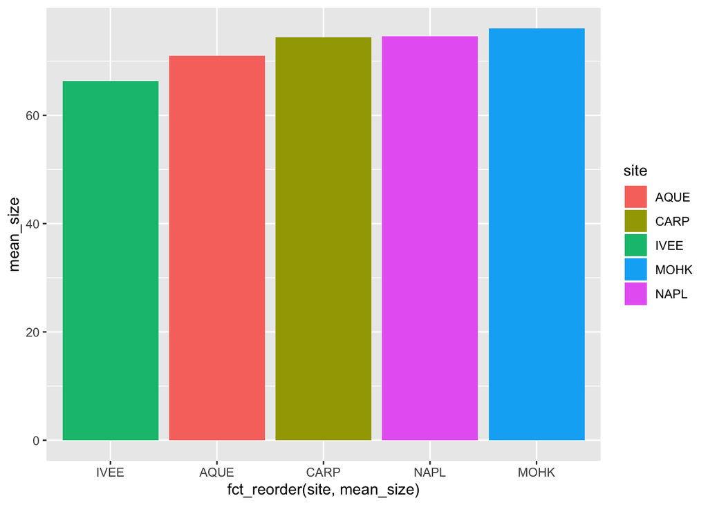

```r
ggplot(lob_df, aes(x = fct_reorder(site, mean_size), y = mean_size, fill = site)) +
  geom_col(position = "dodge") # It automatically arranges alphabetically by site, even though our original data frame is now arranged from low to high mean values.
```

### 6. Some basic hypothesis tests examples in R

We’re going to be using built-in datasets in R to do some basic hypothesis test examples. *Note: The datasets are a great place to just quickly get data to practice with…all existing in R, so you don’t need to load anything in.*

Just run `data()` in the console to see all base datasets, and those in any packages you have loaded! Cool.

#### Two-Sample t-test

Recall: - Null hypothesis: difference in means = 0 - Alternative hypothesis: difference in means is NOT 0

We’ll just create data from scratch (you don’t have to match mine) by producing vectors using the combine (c) function:

```r
sample_1 <- c(4,5,3,1,7,5,3,4,6,4,2,4,4,5,8)
sample_2 <- c(10,11,9,5,6,10,12,15,9,5,7,6,9,10,11)
```

ASSUMING WE’VE DONE ALL NECESSARY EXPLORATORY DATA ANALYSIS, then we can just use t.test() to compare. Check out the defaults using ?t.test

```r
ex_ttest <- t.test(sample_1, sample_2)

ex_ttest
```

```
##
##  Welch Two Sample t-test
##
## data:  sample_1 and sample_2
## t = -5.4261, df = 23.864, p-value = 1.445e-05
## alternative hypothesis: true difference in means is not equal to 0
## 95 percent confidence interval:
##  -6.442254 -2.891080
## sample estimates:
## mean of x mean of y
##  4.333333  9.000000
```

This outcome tells us what conceptually? That if the samples were drawn from populations that truly have the same mean value, then there is only a probability of 0.000014 that we could have found means of our samples that were at LEAST this different by random chance. That’s unlikely. What is way MORE likely is that they were drawn from populations with different means…so my conclusion is “There was a significant difference in [variable] for those measured at Site A and Site B (t = -5.42, p < 0.001).”

Answer: What else might be important metrics to discuss the difference?

- Absolute difference…(more than double, proportional, etc.)
- Effect size (e.g. Cohen’s D)

Note that you CAN do one-sample tests (uncommon) OR one-sided tests, based on what your hypothesis is (if you give it directionality…here, we didn’t).

#### Chi-Square

Reminder of chi-square test for association. Tests for equal proportions existing within each group (the null hypothesis). We’ll create our own data here, too, by making a contingency table from scratch (you might also want to look into the ‘table’ function in R, which will count things up for you…)

```r
df <- tribble(
  ~UCSB, ~UCLA,
  24, 47,
  16, 39
) %>%
  data.matrix() # Since rownames doesn't work on tibbles...

rownames(df) <- c("Pizza","Tacos") # Similarly can use rownames
```

Since chi-square compares proportions (based on the null hypothesis that proportions across groups are the same), then it would be useful to look at the proportions. Use prop.table, and specify whether finding proportions by the entire table (no argument), by columns (2) or rows (1)

```r
prop.table(df, 1) # To find proportions by ROWS
```

```
##            UCSB      UCLA
## Pizza 0.3380282 0.6619718
## Tacos 0.2909091 0.7090909
```

```r
prop.table(df, 2) # To find proportions by COLUMNS
```

```
##       UCSB      UCLA
## Pizza  0.6 0.5465116
## Tacos  0.4 0.4534884
```

```r
prop.table(df) # Proportions across all groups
```

```
##            UCSB      UCLA
## Pizza 0.1904762 0.3730159
## Tacos 0.1269841 0.3095238
```

These are pretty close in terms of proportion of students who chose pizza versus tacos at each school, right? So would this make us tend to think that there IS or is NOT an effect of school on food choice? Probably there is NOT a significant effect. But let’s see…

Once we have data in contingency table format, we can use the chisq.test() function directly on it:

```r
df_chisq <- chisq.test(df)

df_chisq
```

```
##
##  Pearson's Chi-squared test with Yates' continuity correction
##
## data:  df
## X-squared = 0.13733, df = 1, p-value = 0.711
```

As we might expect, there is no significant association between school and food preference ($\chi^2 = 0.14, df = 1, p = 0.71$). You can look up Yates Continuity Correction on your own (for overestimate of X^2 values in 2x2 contingency tables…).

Now let’s move onto some regression with nice output tables.

### 7. OLS

We’ll do basic linear regression using the built-in ‘trees’ dataset (for Girth v Volume) to describe a relationship between the two.

First, look at it (always). Does a linear relationship make sense to consider? We’ll say yes.

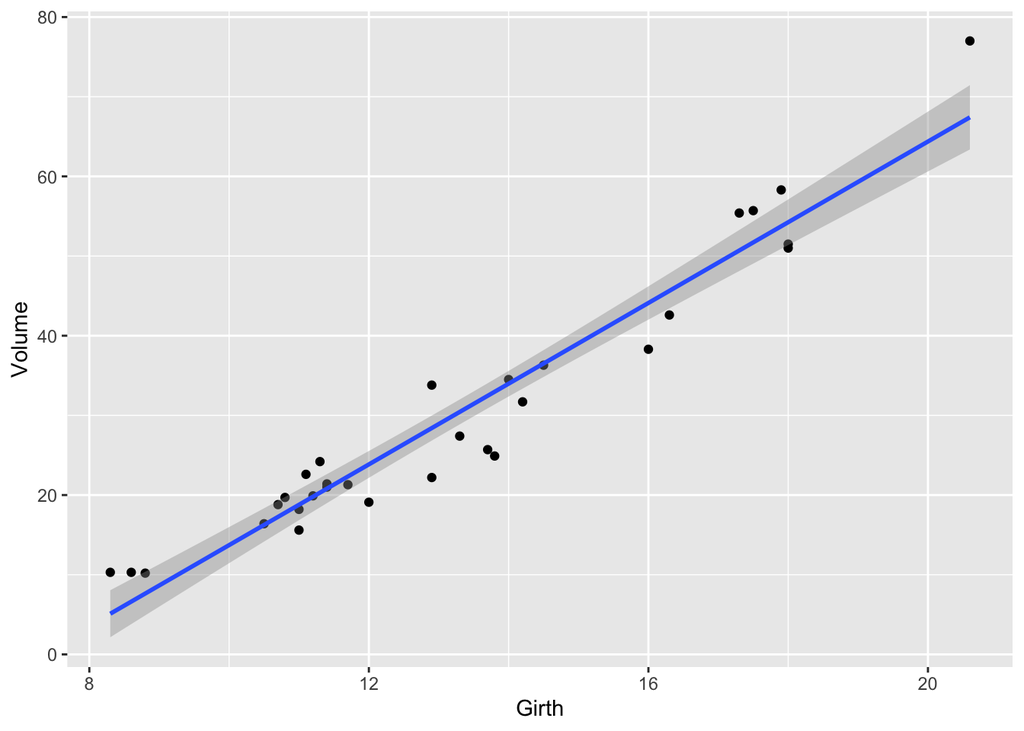

```r
ggplot(trees, aes(x = Girth, y = Volume)) +
  geom_point() +
  geom_smooth(method = "lm")
```

Then, let’s actually prepare the model:

We create models in R using the format:

model_name <- lm(out ~ A + B, data = ?)

```r
tree_lm <- lm(Volume ~ Girth, data = trees)
tree_lm
```

```
##
## Call:
## lm(formula = Volume ~ Girth, data = trees)
##
## Coefficients:
## (Intercept)        Girth
##     -36.943        5.066
```

```r
summary(tree_lm)
```

```
##
## Call:
## lm(formula = Volume ~ Girth, data = trees)
##
## Residuals:
##    Min     1Q Median     3Q    Max
## -8.065 -3.107  0.152  3.495  9.587
##
## Coefficients:
##             Estimate Std. Error t value Pr(>|t|)
## (Intercept) -36.9435     3.3651  -10.98 7.62e-12 ***
## Girth         5.0659     0.2474   20.48  < 2e-16 ***
## ---
## Signif. codes:  0 '***' 0.001 '**' 0.01 '*' 0.05 '.' 0.1 ' ' 1
##
## Residual standard error: 4.252 on 29 degrees of freedom
## Multiple R-squared:  0.9353, Adjusted R-squared:  0.9331
## F-statistic: 419.4 on 1 and 29 DF,  p-value: < 2.2e-16
```

Write out the equation and interpret the p-value for the coefficient for Girth.

But we should want to do some diagnostics on it as well. What’s kind of cool is the plot() function in base R is built to run diagnostics for lm() models:

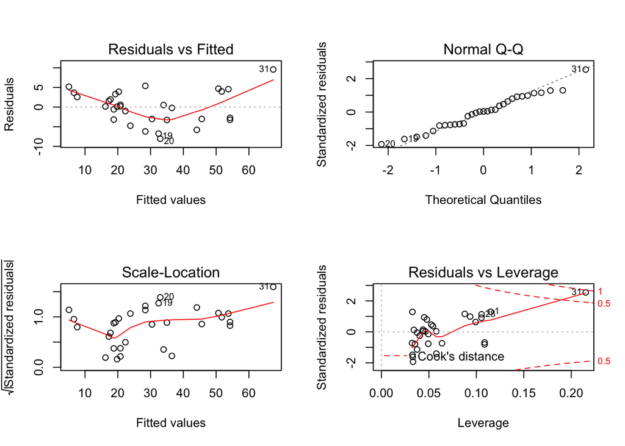

```r
par(mfrow = c(2,2))
plot(tree_lm) # Briefly explain what each of four outputs tell us
```

#### 8. Multiple Linear Regression Example

Now let’s say we want to do multiple linear regression (multiple predictor variables, single continuous outcome variable).

Using the same data, say we think that cherry tree height and girth influence the volume:

```r
tree_mlr <- lm(Volume ~ Height + Girth, data = trees)

tree_mlr
```

```
##
## Call:
## lm(formula = Volume ~ Height + Girth, data = trees)
##
## Coefficients:
## (Intercept)       Height        Girth
##    -57.9877       0.3393       4.7082
```

```r
summary(tree_mlr)
```

```
##
## Call:
## lm(formula = Volume ~ Height + Girth, data = trees)
##
## Residuals:
##     Min      1Q  Median      3Q     Max
## -6.4065 -2.6493 -0.2876  2.2003  8.4847
##
## Coefficients:
##             Estimate Std. Error t value Pr(>|t|)
## (Intercept) -57.9877     8.6382  -6.713 2.75e-07 ***
## Height        0.3393     0.1302   2.607   0.0145 *
## Girth         4.7082     0.2643  17.816  < 2e-16 ***
## ---
## Signif. codes:  0 '***' 0.001 '**' 0.01 '*' 0.05 '.' 0.1 ' ' 1
##
## Residual standard error: 3.882 on 28 degrees of freedom
## Multiple R-squared:  0.948,  Adjusted R-squared:  0.9442
## F-statistic:   255 on 2 and 28 DF,  p-value: < 2.2e-16
```

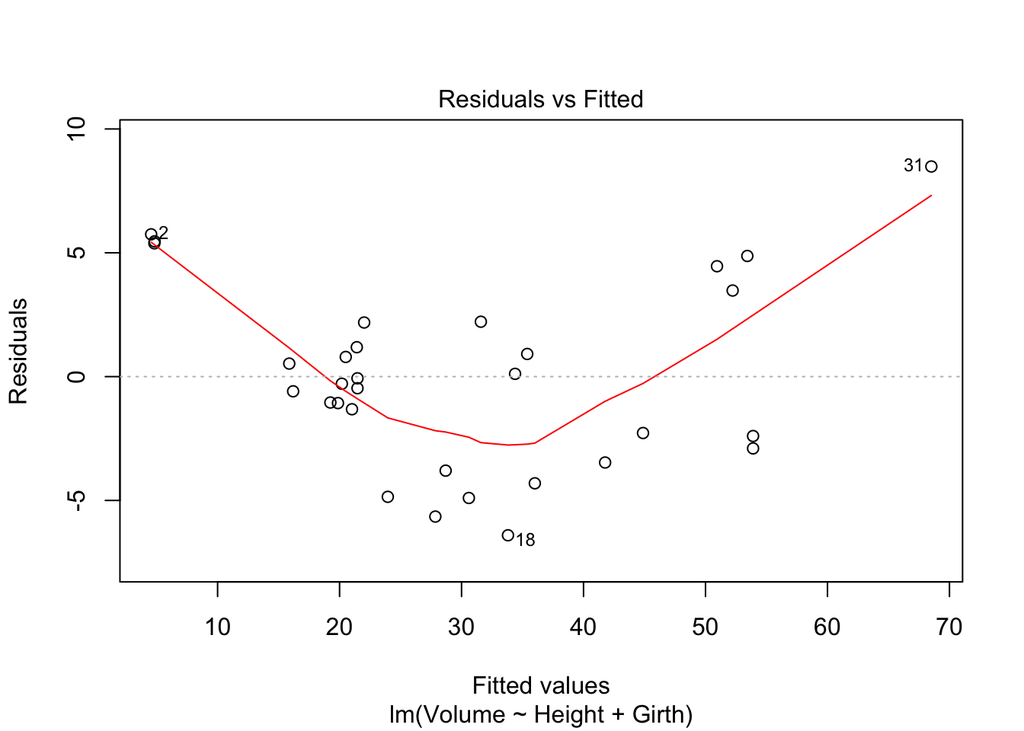

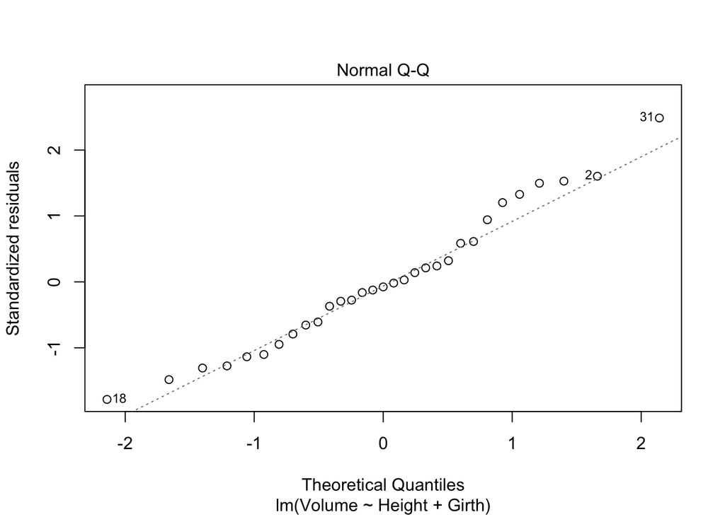

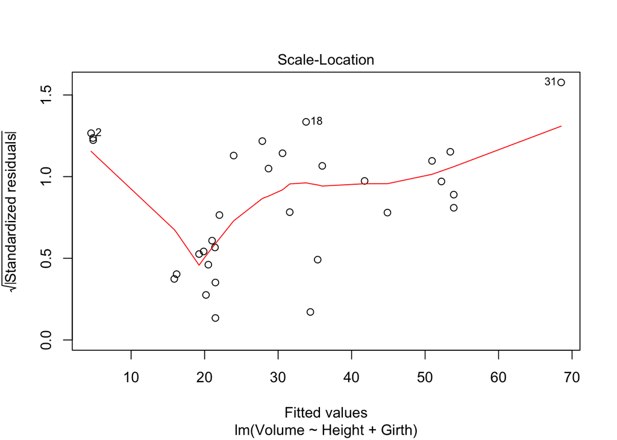

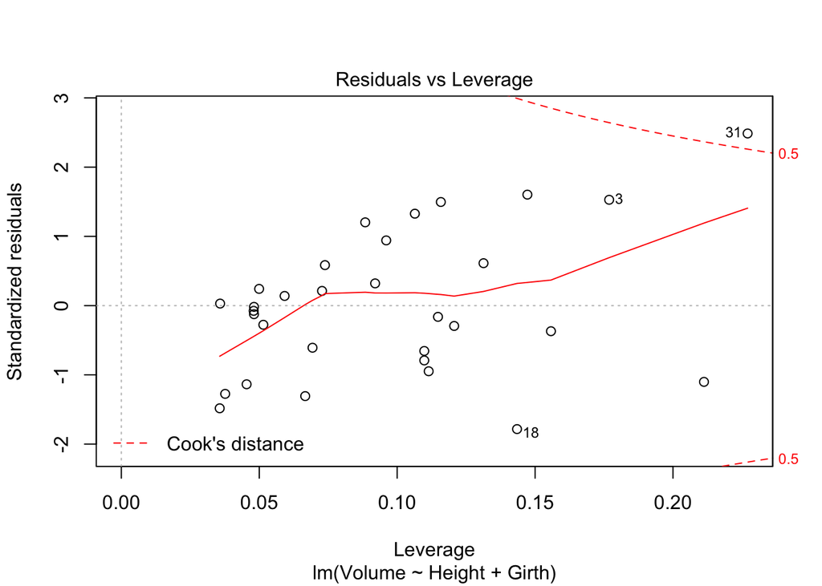

```r
plot(tree_mlr)
```

```r
stargazer(tree_mlr, type = "html")
```

|  | *Dependent variable:* |
| --- | --- |
|  | Volume |
| Height | 0.339** |
|  | (0.130) |
| Girth | 4.708*** |
|  | (0.264) |
| Constant | -57.988*** |
|  | (8.638) |
| Observations | 31 |
| R<sup>2</sup> | 0.948 |
| Adjusted R<sup>2</sup> | 0.944 |
| Residual Std. Error | 3.882 (df = 28) |
| F Statistic | 254.972*** (df = 2; 28) |
| *Note:* | p<0.1; p<0.05; p<0.01 |